# Soil Moisture in Alaska and Alberta

```python
import pandas as pd
import numpy as np
import matplotlib.pyplot as plt
import seaborn as sns
sns.set_theme(rc={'figure.figsize':(15,8.27)})
import datetime as dt
import warnings
warnings.filterwarnings('ignore')
from pandas.api.types import is_object_dtype, is_numeric_dtype, is_bool_dtype
import pprint
import plotly.express as px
import geopandas
import folium
from folium import plugins
import scipy
from scipy.signal import find_peaks
```

## Datasets and schemas

There are 4 tables that we will use:

1. `alaska_probe_period_temp_cal_vmc.csv` AND `alberta_probe_period_temp_cal_vmc.csv` - both contain the soil moisture and temperature (hourly) data for the sites of Sag River, Alaska, USA, and Red Earth Creek in Alberta, Canada (respectively) that were recorded by the data loggers
   - **probe_id** - used as a foreign identifier to access the other tables to get relevant info about a particular probe (corresponds to the **probe** column in the probe coeff table)
   - **timestamp** - datetime
   - **record** - unique record number/ID
   - **batt_V_min** - battery voltage measured in $V$ for the data logger
   - **pa_us_avg_1** - probe period for sample in microseconds, $\mu s$
   - **pa_us_avg_2** - probe period for sample in microseconds, $\mu s$
   - **pa_us_avg_3** - probe period for sample in microseconds, $\mu s$
   - **pa_us_avg_4** - probe period for sample in microseconds, $\mu s$
   - **t109_c_avg** - temperature of the soil measured by probe in degrees celsius
   - **probe1_cal** - (%) calculated volumetric moisture content from probe-specific calibration model
   - **probe2_cal** - (%) calculated volumetric moisture content from probe-specific calibration model
   - **probe3_cal** - (%) calculated volumetric moisture content from probe-specific calibration model
   - **probe4_cal** - (%) calculated volumetric moisture content from probe-specific calibration model

Note that both tables for Alaska and Alberta have the exact same schema.

```python
alaska = pd.read_csv(
    'alaska_probe_period_temp_cal_vmc.csv',
    parse_dates=['time_stamp']
)
alaska.head()
```

|  | probe_id | time_stamp | record | batt_V_min | pa_us_avg_1 | pa_us_avg_2 | pa_us_avg_3 | pa_us_avg_4 | t109_c_avg | probe1_cal | probe2_cal | probe3_cal | probe4_cal |
| --- | --- | --- | --- | --- | --- | --- | --- | --- | --- | --- | --- | --- | --- |
| 0 | 27639.0 | 2017-07-24 18:00:00 | 0.0 | 12.87028 | 38.97705 | 38.60135 | 39.82748 | 39.16694 | 5.402802 | 90.250199 | 83.852354 | 87.988090 | 85.760089 |
| 1 | 27639.0 | 2017-07-24 19:00:00 | 1.0 | 12.42202 | 38.97570 | 38.60542 | 39.84240 | 39.16965 | 5.405273 | 90.245373 | 83.866082 | 88.038415 | 85.769229 |
| 2 | 27639.0 | 2017-07-24 20:00:00 | 2.0 | 12.31709 | 38.97570 | 38.60677 | 39.84375 | 39.17236 | 5.409760 | 90.245373 | 83.870635 | 88.042969 | 85.778370 |
| 3 | 27639.0 | 2017-07-24 21:00:00 | 3.0 | 12.24909 | 38.97705 | 38.60813 | 39.84104 | 39.16287 | 5.419159 | 90.250199 | 83.875222 | 88.033828 | 85.746361 |
| 4 | 27639.0 | 2017-07-24 22:00:00 | 4.0 | 12.19789 | 38.97163 | 38.61356 | 39.83426 | 39.16287 | 5.421631 | 90.230825 | 83.893538 | 88.010959 | 85.746361 |

```python
alberta = pd.read_csv(
    'alberta_probe_period_temp_cal_vmc.csv',
    parse_dates=['time_stamp']
)
alberta
```

|  | probe_id | time_stamp | record | batt_V_min | pa_us_avg_1 | pa_us_avg_2 | pa_us_avg_3 | pa_us_avg_4 | t109_c_avg | probe1_cal | probe2_cal | probe3_cal | probe4_cal |
| --- | --- | --- | --- | --- | --- | --- | --- | --- | --- | --- | --- | --- | --- |
| 0 | NaN | NaT | NaN | NaN | NaN | NaN | NaN | NaN | NaN | NaN | NaN | NaN | NaN |
| 1 | NaN | NaT | NaN | NaN | NaN | NaN | NaN | NaN | NaN | NaN | NaN | NaN | NaN |
| 2 | NaN | NaT | NaN | NaN | NaN | NaN | NaN | NaN | NaN | NaN | NaN | NaN | NaN |
| 3 | NaN | NaT | NaN | NaN | NaN | NaN | NaN | NaN | NaN | NaN | NaN | NaN | NaN |
| 4 | NaN | NaT | NaN | NaN | NaN | NaN | NaN | NaN | NaN | NaN | NaN | NaN | NaN |
| ... | ... | ... | ... | ... | ... | ... | ... | ... | ... | ... | ... | ... | ... |
| 109427 | 13269.0 | 2020-12-06 07:00:00 | 11003.0 | 7.962916 | 19.60585 | 16.93387 | 24.06684 | 17.00033 | -6.198730 | 19.059824 | 11.179282 | 31.276820 | 11.930623 |
| 109428 | 13269.0 | 2020-12-06 08:00:00 | 11004.0 | 13.291670 | 19.60449 | 16.93658 | 24.06413 | 17.00711 | -7.368256 | 19.056682 | 11.189004 | 31.271943 | 11.955543 |
| 109429 | 13269.0 | 2020-12-07 06:00:00 | 11005.0 | 13.399960 | 19.74013 | 17.77344 | 24.42085 | 17.56592 | -7.463715 | 19.365756 | 14.023311 | 31.897059 | 13.967464 |
| 109430 | 13269.0 | 2020-12-07 07:00:00 | 11006.0 | 7.318228 | 19.74962 | 17.82362 | 24.44797 | 17.63102 | -7.564362 | 19.387051 | 14.182619 | 31.943201 | 14.196453 |
| 109431 | 13269.0 | 2020-12-07 08:00:00 | 11007.0 | 12.954220 | 19.75640 | 17.97146 | 24.47510 | 17.77886 | -7.677338 | 19.402238 | 14.644971 | 31.989165 | 14.712297 |

109432 rows × 13 columns

```python
alberta.info()
```

```
<class 'pandas.core.frame.DataFrame'>
RangeIndex: 109432 entries, 0 to 109431
Data columns (total 13 columns):
 #   Column       Non-Null Count  Dtype
---  ------       --------------  -----
 0   probe_id     98411 non-null  float64
 1   time_stamp   98411 non-null  datetime64[ns]
 2   record       98411 non-null  float64
 3   batt_V_min   98411 non-null  float64
 4   pa_us_avg_1  98411 non-null  float64
 5   pa_us_avg_2  98411 non-null  float64
 6   pa_us_avg_3  98411 non-null  float64
 7   pa_us_avg_4  98411 non-null  float64
 8   t109_c_avg   98411 non-null  float64
 9   probe1_cal   98411 non-null  float64
 10  probe2_cal   98411 non-null  float64
 11  probe3_cal   98411 non-null  float64
 12  probe4_cal   98411 non-null  float64
dtypes: datetime64[ns](1), float64(12)
memory usage: 10.9 MB
```

2. `probe_specific_soil_profile_model_coefficients.csv` - contains soil characteristics for both sites
   - **area** - Alaska or Alberta
   - **latitude** and **longitude** - coordinates of probe
   - **plot** - unique ID for each plot with probes
   - **probe** - unique ID for each of the probes. Left number is the sensor ID and right number corresponds to the `pa_us_avg_*` and `probe*_cal`columns in `alaska_probe_period_temp_cal_vmc.csv` and `alberta_probe_period_temp_cal_vmc.csv`
   - **depth_cm** - depth of the probe below the soil surface
   - **organic_contact_pct** - % of the probe that has passed through organic soil
   - **mineral_soil_contact_pct** - % of the probe that has passed through mineral soil
   - **live_moss_pct** - % of the probe that has passed through live moss
   - **dead_moss_pct** - % of the probe that has passed through dead moss
   - **burned_moss_pct** - % of the probe that has passed through burned moss
   - **upper_duff_pct** - % of the probe that has passed through upper duff
   - **lower_duff_pct** - % of the probe that has passed through lower duff
   - **A** - value from applying formula for coefficient A
   - **B** - value from applying formula for coefficient B
   - **C** - value from applying formula for coefficient C

```python
probe_coeff = pd.read_csv(
    'probe_specific_soil_profile_model_coefficients.csv',
    #parse_dates=['time_stamp']
)
probe_coeff
```

|  | area | latitude | longitude | plot | probe | depth_cm | organic_contact_pct | mineral_soil_contact_pct | live_moss_pct | dead_moss_pct | burned_moss_pct | upper_duff_pct | lower_duff_pct | A | B | C |
| --- | --- | --- | --- | --- | --- | --- | --- | --- | --- | --- | --- | --- | --- | --- | --- | --- |
| 0 | Alaska | 69.63300 | -148.68365 | Sedge 1-1 | 27639-1 | 18 | 1.0 | 0.0 | 0.000000 | 0.611110 | 0 | 0.389 | 0.0 | 0.000000 | 3.574484 | -49.072657 |
| 1 | Alaska | 69.63300 | -148.68365 | Sedge 1-1 | 27639-2 | 10 | 1.0 | 0.0 | 0.000000 | 1.000000 | 0 | 0.000 | 0.0 | 0.000000 | 3.373000 | -46.350000 |
| 2 | Alaska | 69.63300 | -148.68365 | Sedge 1-1 | 27639-3 | 10 | 1.0 | 0.0 | 0.000000 | 1.000000 | 0 | 0.000 | 0.0 | 0.000000 | 3.373000 | -46.350000 |
| 3 | Alaska | 69.63300 | -148.68365 | Sedge 1-1 | 27639-4 | 6 | 1.0 | 0.0 | 0.000000 | 1.000000 | 0 | 0.000 | 0.0 | 0.000000 | 3.373000 | -46.350000 |
| 4 | Alaska | 69.63361 | -148.68646 | Sedge 1-4 | 27640-1 | 18 | 1.0 | 0.0 | 0.000000 | 0.000000 | 0 | 0.000 | 0.0 | -0.042800 | 5.387100 | -68.443000 |
| ... | ... | ... | ... | ... | ... | ... | ... | ... | ... | ... | ... | ... | ... | ... | ... | ... |
| 103 | Alberta | 56.73926 | -115.33139 | Treed 1-4 | 23619-4 | 18 | 1.0 | 0.0 | 0.166666 | 0.499999 | 0 | 0.333 | 0.0 | -0.132833 | 8.162359 | -88.547771 |
| 104 | Alberta | 56.73907 | -115.33310 | Treed 1-6 | 13269-1 | 10 | 1.0 | 0.0 | 0.300018 | 0.699982 | 0 | 0.000 | 0.0 | -0.239115 | 11.686508 | -118.150985 |
| 105 | Alberta | 56.73907 | -115.33310 | Treed 1-6 | 13269-2 | 10 | 1.0 | 0.0 | 0.300018 | 0.699982 | 0 | 0.000 | 0.0 | -0.239115 | 11.686508 | -118.150985 |
| 106 | Alberta | 56.73907 | -115.33310 | Treed 1-6 | 13269-3 | 18 | 1.0 | 0.0 | 0.166666 | 0.444444 | 0 | 0.389 | 0.0 | -0.132833 | 8.192810 | -88.959591 |
| 107 | Alberta | 56.73907 | -115.33310 | Treed 1-6 | 13269-4 | 18 | 1.0 | 0.0 | 0.166666 | 0.444444 | 0 | 0.389 | 0.0 | -0.132833 | 8.192810 | -88.959591 |

108 rows × 16 columns

```python
probe_coeff.info()
```

```
<class 'pandas.core.frame.DataFrame'>
RangeIndex: 108 entries, 0 to 107
Data columns (total 16 columns):
 #   Column                    Non-Null Count  Dtype
---  ------                    --------------  -----
 0   area                      108 non-null    object
 1   latitude                  108 non-null    float64
 2   longitude                 108 non-null    float64
 3   plot                      108 non-null    object
 4   probe                     108 non-null    object
 5   depth_cm                  108 non-null    int64
 6   organic_contact_pct       108 non-null    float64
 7   mineral_soil_contact_pct  108 non-null    float64
 8   live_moss_pct             108 non-null    float64
 9   dead_moss_pct             108 non-null    float64
 10  burned_moss_pct           108 non-null    int64
 11  upper_duff_pct            108 non-null    float64
 12  lower_duff_pct            108 non-null    float64
 13  A                         108 non-null    float64
 14  B                         108 non-null    float64
 15  C                         108 non-null    float64
dtypes: float64(11), int64(2), object(3)
memory usage: 13.6+ KB
```

`soil_moisture_model_coefficients.csv` - contains the model coefficients for calibrating soil moisture loggers for each soil type. Volumetric moisture content is calculated as follows:

\begin{align} VMC = A\cdot x^{2} + B\cdot x + C \end{align}

where $x$ is the probe period

- **Soil_type** - type of soil
- **A** - coefficient for variable A in models
- **B** - coefficient for variable B in models
- **C** - coefficient for variable C in models

```python
soil_coeff = pd.read_csv(
    'soil_moisture_model_coefficients.csv',
    #parse_dates=['time_stamp']
)
soil_coeff
```

|  | Soil_type | A | B | C |
| --- | --- | --- | --- | --- |
| 0 | Default | 0.0700 | -0.6300 | -6.6300 |
| 1 | Live Moss | -0.7970 | 31.0830 | -285.6720 |
| 2 | Dead Moss | 0.0000 | 3.3730 | -46.3500 |
| 3 | Burned Moss | 0.0000 | 6.0450 | -88.4690 |
| 4 | Upper Duff | 0.0000 | 3.8900 | -53.3360 |
| 5 | Lower Duff | 0.0000 | 2.9230 | -41.9150 |
| 6 | Mineral Soil | 0.0827 | 0.0000 | -16.7259 |
| 7 | Combined | -0.0428 | 5.3871 | -68.4430 |

```python
soil_coeff.info()
```

```
<class 'pandas.core.frame.DataFrame'>
RangeIndex: 8 entries, 0 to 7
Data columns (total 4 columns):
 #   Column     Non-Null Count  Dtype
---  ------     --------------  -----
 0   Soil_type  8 non-null      object
 1   A          8 non-null      float64
 2   B          8 non-null      float64
 3   C          8 non-null      float64
dtypes: float64(3), object(1)
memory usage: 388.0+ bytes
```

## Clean the data

### Change data type

```python
# alaska and alberta have the correct data types for all columns, except probe_id - needs to be int later
# probe_coeff and soil_coeff have a few object columns that need to be changed to string

probe_coeff_obj_cols = list(probe_coeff.select_dtypes(include='object'))
soil_coeff_obj_cols = list(soil_coeff.select_dtypes(include='object'))

def change_data_type(df, cols, data_type):
    for col in cols:
        df[col] = df[col].astype(data_type)
    return df

probe_coeff = change_data_type(probe_coeff, probe_coeff_obj_cols, "string")
soil_coeff = change_data_type(soil_coeff, soil_coeff_obj_cols, "string")
```

```python
# check
print(probe_coeff.info())
print(soil_coeff.info())
```

```
<class 'pandas.core.frame.DataFrame'>
RangeIndex: 108 entries, 0 to 107
Data columns (total 16 columns):
 #   Column                    Non-Null Count  Dtype
---  ------                    --------------  -----
 0   area                      108 non-null    string
 1   latitude                  108 non-null    float64
 2   longitude                 108 non-null    float64
 3   plot                      108 non-null    string
 4   probe                     108 non-null    string
 5   depth_cm                  108 non-null    int64
 6   organic_contact_pct       108 non-null    float64
 7   mineral_soil_contact_pct  108 non-null    float64
 8   live_moss_pct             108 non-null    float64
 9   dead_moss_pct             108 non-null    float64
 10  burned_moss_pct           108 non-null    int64
 11  upper_duff_pct            108 non-null    float64
 12  lower_duff_pct            108 non-null    float64
 13  A                         108 non-null    float64
 14  B                         108 non-null    float64
 15  C                         108 non-null    float64
dtypes: float64(11), int64(2), string(3)
memory usage: 13.6 KB
None
<class 'pandas.core.frame.DataFrame'>
RangeIndex: 8 entries, 0 to 7
Data columns (total 4 columns):
 #   Column     Non-Null Count  Dtype
---  ------     --------------  -----
 0   Soil_type  8 non-null      string
 1   A          8 non-null      float64
 2   B          8 non-null      float64
 3   C          8 non-null      float64
dtypes: float64(3), string(1)
memory usage: 388.0 bytes
None
```

### Handle missing data

The data guide states that all numeric missing values are denoted as -9999 and all the text missing values are denoted by "NA". Looking at df.info() will tell us the proportions of the missing values denoted as null, but this is not representative of the other missing valies denoted as -9999 or "NA". So lets use this information to look at the entire distribution of missing data and decide if we should drop rows/columns with those missing values, or use an imputation method.

```python
alaska.info()
```

```
<class 'pandas.core.frame.DataFrame'>
RangeIndex: 159335 entries, 0 to 159334
Data columns (total 13 columns):
 #   Column       Non-Null Count   Dtype
---  ------       --------------   -----
 0   probe_id     159321 non-null  float64
 1   time_stamp   159321 non-null  datetime64[ns]
 2   record       159321 non-null  float64
 3   batt_V_min   159321 non-null  float64
 4   pa_us_avg_1  159321 non-null  float64
 5   pa_us_avg_2  159321 non-null  float64
 6   pa_us_avg_3  159321 non-null  float64
 7   pa_us_avg_4  159321 non-null  float64
 8   t109_c_avg   159321 non-null  float64
 9   probe1_cal   159321 non-null  float64
 10  probe2_cal   159321 non-null  float64
 11  probe3_cal   159321 non-null  float64
 12  probe4_cal   159321 non-null  float64
dtypes: datetime64[ns](1), float64(12)
memory usage: 15.8 MB
```

```python
alberta.info()
```

```
<class 'pandas.core.frame.DataFrame'>
RangeIndex: 109432 entries, 0 to 109431
Data columns (total 13 columns):
 #   Column       Non-Null Count  Dtype
---  ------       --------------  -----
 0   probe_id     98411 non-null  float64
 1   time_stamp   98411 non-null  datetime64[ns]
 2   record       98411 non-null  float64
 3   batt_V_min   98411 non-null  float64
 4   pa_us_avg_1  98411 non-null  float64
 5   pa_us_avg_2  98411 non-null  float64
 6   pa_us_avg_3  98411 non-null  float64
 7   pa_us_avg_4  98411 non-null  float64
 8   t109_c_avg   98411 non-null  float64
 9   probe1_cal   98411 non-null  float64
 10  probe2_cal   98411 non-null  float64
 11  probe3_cal   98411 non-null  float64
 12  probe4_cal   98411 non-null  float64
dtypes: datetime64[ns](1), float64(12)
memory usage: 10.9 MB
```

```python
probe_coeff.info()
```

```
<class 'pandas.core.frame.DataFrame'>
RangeIndex: 108 entries, 0 to 107
Data columns (total 16 columns):
 #   Column                    Non-Null Count  Dtype
---  ------                    --------------  -----
 0   area                      108 non-null    string
 1   latitude                  108 non-null    float64
 2   longitude                 108 non-null    float64
 3   plot                      108 non-null    string
 4   probe                     108 non-null    string
 5   depth_cm                  108 non-null    int64
 6   organic_contact_pct       108 non-null    float64
 7   mineral_soil_contact_pct  108 non-null    float64
 8   live_moss_pct             108 non-null    float64
 9   dead_moss_pct             108 non-null    float64
 10  burned_moss_pct           108 non-null    int64
 11  upper_duff_pct            108 non-null    float64
 12  lower_duff_pct            108 non-null    float64
 13  A                         108 non-null    float64
 14  B                         108 non-null    float64
 15  C                         108 non-null    float64
dtypes: float64(11), int64(2), string(3)
memory usage: 13.6 KB
```

```python
soil_coeff.info()
```

```
<class 'pandas.core.frame.DataFrame'>
RangeIndex: 8 entries, 0 to 7
Data columns (total 4 columns):
 #   Column     Non-Null Count  Dtype
---  ------     --------------  -----
 0   Soil_type  8 non-null      string
 1   A          8 non-null      float64
 2   B          8 non-null      float64
 3   C          8 non-null      float64
dtypes: float64(3), string(1)
memory usage: 388.0 bytes
```

Alaska and alberta dataframes are the only ones that have missing values denoted by null. Probe_coeff and soil_coeff don't have any nulls, but we will check all four dataframes for the other inconsistent/missing values.

```python
def check_missing_data(df, data_type):

    '''
    This function will check the dataframe for missing values based on the criteria explained in the sections
    above (i.e., -9999, NA, or null)

    Args:
        df (Pandas Dataframe) : the dataframe we are checking for missing and inconsistent values
              data_type (str) : the datatype we will filter the df (since some missing values are denoted
                                differently for numerical and text columns)

    Returns:
        dictionary : the proportions of TOTAL missing values (null and filled in with -9999 or "NA") of each column

    '''

    if data_type == "numerical":
        # get all columns with int data types
        cols = df.loc[:, (df.dtypes == "float64") | (df.dtypes == "int64")].columns

        # count how many rows contain either a null or -9999 for numerical values

        proportions = np.array(
            np.round(
                (((df[cols].isnull()) | (df[cols] == -9999)).sum()/len(df))*100,
                    5
                )
            )
        return pprint.pformat(dict(zip(cols,  proportions)))

    elif data_type == "string": # change to string later
        cols = df.loc[:, (df.dtypes == "string")].columns
        # count how many rows contain either a null or NA for text values

        proportions = np.array(
            np.round(
                (((df[cols].isnull()) | (df[cols] == "NA")).sum()/len(df))*100,
                    5
                )
            )
        return pprint.pformat(dict(zip(cols,  proportions)))
```

```python
# numerical only dataframes

print("% of missing data in alaska numerical columns:\n", check_missing_data(alaska, "numerical"), '\n')
print("% of missing data in alberta numerical columns:\n", check_missing_data(alberta, "numerical"), '\n')

# both numerical and strings

print("% of missing data in probe coefficient numerical columns:\n", check_missing_data(probe_coeff, "numerical"), '\n')
print("% of missing data in probe coefficient string columns:\n", check_missing_data(probe_coeff, "string"), '\n')

print("% of missing data in soil coefficient numerical columns:\n", check_missing_data(soil_coeff, "numerical"), '\n')
print("% of missing data in soil coefficient string columns:\n", check_missing_data(soil_coeff, "string"), '\n')
```

```
% of missing data in alaska numerical columns:
 {'batt_V_min': 0.00879,
 'pa_us_avg_1': 0.02573,
 'pa_us_avg_2': 0.02008,
 'pa_us_avg_3': 0.02824,
 'pa_us_avg_4': 0.72238,
 'probe1_cal': 0.02573,
 'probe2_cal': 0.02008,
 'probe3_cal': 0.02824,
 'probe4_cal': 0.72238,
 'probe_id': 0.00879,
 'record': 0.00879,
 't109_c_avg': 0.00941}

% of missing data in alberta numerical columns:
 {'batt_V_min': 10.07109,
 'pa_us_avg_1': 10.09394,
 'pa_us_avg_2': 11.52314,
 'pa_us_avg_3': 10.10491,
 'pa_us_avg_4': 11.64376,
 'probe1_cal': 10.09303,
 'probe2_cal': 11.52131,
 'probe3_cal': 10.10216,
 'probe4_cal': 11.64285,
 'probe_id': 10.07109,
 'record': 10.07109,
 't109_c_avg': 10.07109}

% of missing data in probe coefficient numerical columns:
 {'A': 0.0,
 'B': 0.0,
 'C': 0.0,
 'burned_moss_pct': 0.0,
 'dead_moss_pct': 0.0,
 'depth_cm': 0.0,
 'latitude': 0.0,
 'live_moss_pct': 0.0,
 'longitude': 0.0,
 'lower_duff_pct': 0.0,
 'mineral_soil_contact_pct': 0.0,
 'organic_contact_pct': 0.0,
 'upper_duff_pct': 0.0}

% of missing data in probe coefficient string columns:
 {'area': 0.0, 'plot': 0.0, 'probe': 0.0}

% of missing data in soil coefficient numerical columns:
 {'A': 0.0, 'B': 0.0, 'C': 0.0}

% of missing data in soil coefficient string columns:
 {'Soil_type': 0.0}
```

The distributions of missing data (null, -9999, and NA) are less than 1% for `alaska` and between 10-12% for `alberta`. For both dataframes, we will drop the rows that are part of a consecutive group of nulls and keep the nulls that appear singularly.

```python
alberta_consec_nulls = alberta['probe_id'].isnull() & alberta['probe_id'].shift().isnull()
alaska_consec_nulls = alaska['probe_id'].isnull() & alaska['probe_id'].shift().isnull()

alberta_cleaned = alberta[~alberta_consec_nulls]
alaska_cleaned = alaska[~alaska_consec_nulls]
```

```python
alberta_cleaned.info()
```

```
<class 'pandas.core.frame.DataFrame'>
Index: 98432 entries, 700 to 109431
Data columns (total 13 columns):
 #   Column       Non-Null Count  Dtype
---  ------       --------------  -----
 0   probe_id     98411 non-null  float64
 1   time_stamp   98411 non-null  datetime64[ns]
 2   record       98411 non-null  float64
 3   batt_V_min   98411 non-null  float64
 4   pa_us_avg_1  98411 non-null  float64
 5   pa_us_avg_2  98411 non-null  float64
 6   pa_us_avg_3  98411 non-null  float64
 7   pa_us_avg_4  98411 non-null  float64
 8   t109_c_avg   98411 non-null  float64
 9   probe1_cal   98411 non-null  float64
 10  probe2_cal   98411 non-null  float64
 11  probe3_cal   98411 non-null  float64
 12  probe4_cal   98411 non-null  float64
dtypes: datetime64[ns](1), float64(12)
memory usage: 10.5 MB
```

```python
alaska_cleaned.info()
```

```
<class 'pandas.core.frame.DataFrame'>
RangeIndex: 159335 entries, 0 to 159334
Data columns (total 13 columns):
 #   Column       Non-Null Count   Dtype
---  ------       --------------   -----
 0   probe_id     159321 non-null  float64
 1   time_stamp   159321 non-null  datetime64[ns]
 2   record       159321 non-null  float64
 3   batt_V_min   159321 non-null  float64
 4   pa_us_avg_1  159321 non-null  float64
 5   pa_us_avg_2  159321 non-null  float64
 6   pa_us_avg_3  159321 non-null  float64
 7   pa_us_avg_4  159321 non-null  float64
 8   t109_c_avg   159321 non-null  float64
 9   probe1_cal   159321 non-null  float64
 10  probe2_cal   159321 non-null  float64
 11  probe3_cal   159321 non-null  float64
 12  probe4_cal   159321 non-null  float64
dtypes: datetime64[ns](1), float64(12)
memory usage: 15.8 MB
```

```python
alaska_cleaned = alaska_cleaned.replace(-9999, np.nan).dropna()
alberta_cleaned = alberta_cleaned.replace(-9999, np.nan).dropna()
```

```python
alaska_cleaned.info()
```

```
<class 'pandas.core.frame.DataFrame'>
Index: 158151 entries, 0 to 159334
Data columns (total 13 columns):
 #   Column       Non-Null Count   Dtype
---  ------       --------------   -----
 0   probe_id     158151 non-null  float64
 1   time_stamp   158151 non-null  datetime64[ns]
 2   record       158151 non-null  float64
 3   batt_V_min   158151 non-null  float64
 4   pa_us_avg_1  158151 non-null  float64
 5   pa_us_avg_2  158151 non-null  float64
 6   pa_us_avg_3  158151 non-null  float64
 7   pa_us_avg_4  158151 non-null  float64
 8   t109_c_avg   158151 non-null  float64
 9   probe1_cal   158151 non-null  float64
 10  probe2_cal   158151 non-null  float64
 11  probe3_cal   158151 non-null  float64
 12  probe4_cal   158151 non-null  float64
dtypes: datetime64[ns](1), float64(12)
memory usage: 16.9 MB
```

```python
alberta_cleaned.info()
```

```
<class 'pandas.core.frame.DataFrame'>
Index: 95429 entries, 700 to 109431
Data columns (total 13 columns):
 #   Column       Non-Null Count  Dtype
---  ------       --------------  -----
 0   probe_id     95429 non-null  float64
 1   time_stamp   95429 non-null  datetime64[ns]
 2   record       95429 non-null  float64
 3   batt_V_min   95429 non-null  float64
 4   pa_us_avg_1  95429 non-null  float64
 5   pa_us_avg_2  95429 non-null  float64
 6   pa_us_avg_3  95429 non-null  float64
 7   pa_us_avg_4  95429 non-null  float64
 8   t109_c_avg   95429 non-null  float64
 9   probe1_cal   95429 non-null  float64
 10  probe2_cal   95429 non-null  float64
 11  probe3_cal   95429 non-null  float64
 12  probe4_cal   95429 non-null  float64
dtypes: datetime64[ns](1), float64(12)
memory usage: 10.2 MB
```

```python
# convert the probe_id column to int

alaska_cleaned = change_data_type(alaska_cleaned, ['probe_id', 'record'], 'int')
alberta_cleaned = change_data_type(alberta_cleaned, ['probe_id', 'record'], 'int')
```

```python
alaska_cleaned.head()
```

|  | probe_id | time_stamp | record | batt_V_min | pa_us_avg_1 | pa_us_avg_2 | pa_us_avg_3 | pa_us_avg_4 | t109_c_avg | probe1_cal | probe2_cal | probe3_cal | probe4_cal |
| --- | --- | --- | --- | --- | --- | --- | --- | --- | --- | --- | --- | --- | --- |
| 0 | 27639 | 2017-07-24 18:00:00 | 0 | 12.87028 | 38.97705 | 38.60135 | 39.82748 | 39.16694 | 5.402802 | 90.250199 | 83.852354 | 87.988090 | 85.760089 |
| 1 | 27639 | 2017-07-24 19:00:00 | 1 | 12.42202 | 38.97570 | 38.60542 | 39.84240 | 39.16965 | 5.405273 | 90.245373 | 83.866082 | 88.038415 | 85.769229 |
| 2 | 27639 | 2017-07-24 20:00:00 | 2 | 12.31709 | 38.97570 | 38.60677 | 39.84375 | 39.17236 | 5.409760 | 90.245373 | 83.870635 | 88.042969 | 85.778370 |
| 3 | 27639 | 2017-07-24 21:00:00 | 3 | 12.24909 | 38.97705 | 38.60813 | 39.84104 | 39.16287 | 5.419159 | 90.250199 | 83.875222 | 88.033828 | 85.746361 |
| 4 | 27639 | 2017-07-24 22:00:00 | 4 | 12.19789 | 38.97163 | 38.61356 | 39.83426 | 39.16287 | 5.421631 | 90.230825 | 83.893538 | 88.010959 | 85.746361 |

```python
probe_coeff.head()
```

|  | area | latitude | longitude | plot | probe | depth_cm | organic_contact_pct | mineral_soil_contact_pct | live_moss_pct | dead_moss_pct | burned_moss_pct | upper_duff_pct | lower_duff_pct | A | B | C |
| --- | --- | --- | --- | --- | --- | --- | --- | --- | --- | --- | --- | --- | --- | --- | --- | --- |
| 0 | Alaska | 69.63300 | -148.68365 | Sedge 1-1 | 27639-1 | 18 | 1.0 | 0.0 | 0.0 | 0.61111 | 0 | 0.389 | 0.0 | 0.0000 | 3.574484 | -49.072657 |
| 1 | Alaska | 69.63300 | -148.68365 | Sedge 1-1 | 27639-2 | 10 | 1.0 | 0.0 | 0.0 | 1.00000 | 0 | 0.000 | 0.0 | 0.0000 | 3.373000 | -46.350000 |
| 2 | Alaska | 69.63300 | -148.68365 | Sedge 1-1 | 27639-3 | 10 | 1.0 | 0.0 | 0.0 | 1.00000 | 0 | 0.000 | 0.0 | 0.0000 | 3.373000 | -46.350000 |
| 3 | Alaska | 69.63300 | -148.68365 | Sedge 1-1 | 27639-4 | 6 | 1.0 | 0.0 | 0.0 | 1.00000 | 0 | 0.000 | 0.0 | 0.0000 | 3.373000 | -46.350000 |
| 4 | Alaska | 69.63361 | -148.68646 | Sedge 1-4 | 27640-1 | 18 | 1.0 | 0.0 | 0.0 | 0.00000 | 0 | 0.000 | 0.0 | -0.0428 | 5.387100 | -68.443000 |

## Manipulate some columns

Extract datetime

```python
def extract_date(df):

    df['min'] = df['time_stamp'].dt.minute
    df['hour'] = df['time_stamp'].dt.hour
    df['day'] = df['time_stamp'].dt.day
    df['month'] = df['time_stamp'].dt.month
    df['year'] = df['time_stamp'].dt.year

    return df

alaska_cleaned=extract_date(alaska_cleaned)
alberta_cleaned=extract_date(alberta_cleaned)
```

```python
alaska_cleaned.head()
```

|  | probe_id | time_stamp | record | batt_V_min | pa_us_avg_1 | pa_us_avg_2 | pa_us_avg_3 | pa_us_avg_4 | t109_c_avg | probe1_cal | probe2_cal | probe3_cal | probe4_cal | min | hour | day | month | year |
| --- | --- | --- | --- | --- | --- | --- | --- | --- | --- | --- | --- | --- | --- | --- | --- | --- | --- | --- |
| 0 | 27639 | 2017-07-24 18:00:00 | 0 | 12.87028 | 38.97705 | 38.60135 | 39.82748 | 39.16694 | 5.402802 | 90.250199 | 83.852354 | 87.988090 | 85.760089 | 0 | 18 | 24 | 7 | 2017 |
| 1 | 27639 | 2017-07-24 19:00:00 | 1 | 12.42202 | 38.97570 | 38.60542 | 39.84240 | 39.16965 | 5.405273 | 90.245373 | 83.866082 | 88.038415 | 85.769229 | 0 | 19 | 24 | 7 | 2017 |
| 2 | 27639 | 2017-07-24 20:00:00 | 2 | 12.31709 | 38.97570 | 38.60677 | 39.84375 | 39.17236 | 5.409760 | 90.245373 | 83.870635 | 88.042969 | 85.778370 | 0 | 20 | 24 | 7 | 2017 |
| 3 | 27639 | 2017-07-24 21:00:00 | 3 | 12.24909 | 38.97705 | 38.60813 | 39.84104 | 39.16287 | 5.419159 | 90.250199 | 83.875222 | 88.033828 | 85.746361 | 0 | 21 | 24 | 7 | 2017 |
| 4 | 27639 | 2017-07-24 22:00:00 | 4 | 12.19789 | 38.97163 | 38.61356 | 39.83426 | 39.16287 | 5.421631 | 90.230825 | 83.893538 | 88.010959 | 85.746361 | 0 | 22 | 24 | 7 | 2017 |

According to the guide, the table `probe_coeff` has a column called `probe` that represents a unique ID for each of the probes made up of 2 important numbers. The ID is in the form of `<left number> - <right number>` where the left number before the hyphen corresponds to the sensor ID, and the right number after the hyphen corresponds to the columns `pa_us_avg_*` and `probe*_cal` in the `alberta` and `alaska` dataframes.

For ease of joining these tables, we will manipulate the `probe` column in `probe_coeff` to extract these 2 unique ID values and create separte columns for them.

```python
split_probe = np.array(probe_coeff['probe'].str.split('-'))
split_probe = np.array([np.array(item) if isinstance(item, list) else item for item in split_probe]).T

probe_coeff['probe_id'] = split_probe[0].astype('int')
probe_coeff['record'] = split_probe[1].astype('int')
```

```python
probe_coeff.head()
```

|  | area | latitude | longitude | plot | probe | depth_cm | organic_contact_pct | mineral_soil_contact_pct | live_moss_pct | dead_moss_pct | burned_moss_pct | upper_duff_pct | lower_duff_pct | A | B | C | probe_id | record |
| --- | --- | --- | --- | --- | --- | --- | --- | --- | --- | --- | --- | --- | --- | --- | --- | --- | --- | --- |
| 0 | Alaska | 69.63300 | -148.68365 | Sedge 1-1 | 27639-1 | 18 | 1.0 | 0.0 | 0.0 | 0.61111 | 0 | 0.389 | 0.0 | 0.0000 | 3.574484 | -49.072657 | 27639 | 1 |
| 1 | Alaska | 69.63300 | -148.68365 | Sedge 1-1 | 27639-2 | 10 | 1.0 | 0.0 | 0.0 | 1.00000 | 0 | 0.000 | 0.0 | 0.0000 | 3.373000 | -46.350000 | 27639 | 2 |
| 2 | Alaska | 69.63300 | -148.68365 | Sedge 1-1 | 27639-3 | 10 | 1.0 | 0.0 | 0.0 | 1.00000 | 0 | 0.000 | 0.0 | 0.0000 | 3.373000 | -46.350000 | 27639 | 3 |
| 3 | Alaska | 69.63300 | -148.68365 | Sedge 1-1 | 27639-4 | 6 | 1.0 | 0.0 | 0.0 | 1.00000 | 0 | 0.000 | 0.0 | 0.0000 | 3.373000 | -46.350000 | 27639 | 4 |
| 4 | Alaska | 69.63361 | -148.68646 | Sedge 1-4 | 27640-1 | 18 | 1.0 | 0.0 | 0.0 | 0.00000 | 0 | 0.000 | 0.0 | -0.0428 | 5.387100 | -68.443000 | 27640 | 1 |

```python
alaska_cleaned['probe_id']=alaska_cleaned['probe_id'].astype('int')
alberta_cleaned['probe_id']=alberta_cleaned['probe_id'].astype('int')
```

## Where are the areas in our datasets?

```python
# location should be a mid point between alaska and alberta

def find_midpoint(x1, y1, x2, y2):
    '''
    These values are a mean of the latitudes and longitudes

    x1 : mean of the alaska latitudes
    y1 : mean of the alberta latitudes
    x2 : mean of the alaska longitudes
    y2 : mean of the alberta longitudes

    '''

    return [(x1+y1)/2, (x2+y2)/2]

midpoint = find_midpoint(
    x1=np.mean(probe_coeff[probe_coeff['area']=='Alaska'].latitude),
    y1=np.mean(probe_coeff[probe_coeff['area']=='Alberta'].latitude),
    x2=np.mean(probe_coeff[probe_coeff['area']=='Alaska'].longitude),
    y2=np.mean(probe_coeff[probe_coeff['area']=='Alberta'].longitude)
)

all_map = folium.Map(location=midpoint, tiles="OpenTopoMap", zoom_start=4)

for lat, long in zip(probe_coeff.latitude, probe_coeff.longitude):

    folium.Marker(location=[lat, long]).add_to(all_map)

all_map
```

Make this Notebook Trusted to load map: File -> Trust Notebook

[interactive chart not shown]

```python
# look a little closer at alaska and alberta separately

alaska_map = folium.Map(
    location=[
        np.mean(probe_coeff[probe_coeff['area']=='Alaska'].latitude),
        np.mean(probe_coeff[probe_coeff['area']=='Alaska'].longitude)
    ],
    tiles="OpenTopoMap",
    zoom_start=8
)

for lat, long in zip(probe_coeff[probe_coeff['area']=='Alaska'].latitude, probe_coeff[probe_coeff['area']=='Alaska'].longitude):

    folium.Marker(location=[lat, long]).add_to(alaska_map)

alaska_map
```

Make this Notebook Trusted to load map: File -> Trust Notebook

[interactive chart not shown]

```python
# look a little closer at alaska and alberta separately

alberta_map = folium.Map(
    location=[
        np.mean(probe_coeff[probe_coeff['area']=='Alberta'].latitude),
        np.mean(probe_coeff[probe_coeff['area']=='Alberta'].longitude)
    ],
    tiles="OpenTopoMap",
    zoom_start=8
)

for lat, long in zip(probe_coeff[probe_coeff['area']=='Alberta'].latitude, probe_coeff[probe_coeff['area']=='Alberta'].longitude):

    folium.Marker(location=[lat, long]).add_to(alberta_map)

alberta_map
```

Make this Notebook Trusted to load map: File -> Trust Notebook

[interactive chart not shown]

```python
probe_coeff.head()
```

|  | area | latitude | longitude | plot | probe | depth_cm | organic_contact_pct | mineral_soil_contact_pct | live_moss_pct | dead_moss_pct | burned_moss_pct | upper_duff_pct | lower_duff_pct | A | B | C | probe_id | record |
| --- | --- | --- | --- | --- | --- | --- | --- | --- | --- | --- | --- | --- | --- | --- | --- | --- | --- | --- |
| 0 | Alaska | 69.63300 | -148.68365 | Sedge 1-1 | 27639-1 | 18 | 1.0 | 0.0 | 0.0 | 0.61111 | 0 | 0.389 | 0.0 | 0.0000 | 3.574484 | -49.072657 | 27639 | 1 |
| 1 | Alaska | 69.63300 | -148.68365 | Sedge 1-1 | 27639-2 | 10 | 1.0 | 0.0 | 0.0 | 1.00000 | 0 | 0.000 | 0.0 | 0.0000 | 3.373000 | -46.350000 | 27639 | 2 |
| 2 | Alaska | 69.63300 | -148.68365 | Sedge 1-1 | 27639-3 | 10 | 1.0 | 0.0 | 0.0 | 1.00000 | 0 | 0.000 | 0.0 | 0.0000 | 3.373000 | -46.350000 | 27639 | 3 |
| 3 | Alaska | 69.63300 | -148.68365 | Sedge 1-1 | 27639-4 | 6 | 1.0 | 0.0 | 0.0 | 1.00000 | 0 | 0.000 | 0.0 | 0.0000 | 3.373000 | -46.350000 | 27639 | 4 |
| 4 | Alaska | 69.63361 | -148.68646 | Sedge 1-4 | 27640-1 | 18 | 1.0 | 0.0 | 0.0 | 0.00000 | 0 | 0.000 | 0.0 | -0.0428 | 5.387100 | -68.443000 | 27640 | 1 |

```python
probe_coeff.info()
```

```
<class 'pandas.core.frame.DataFrame'>
RangeIndex: 108 entries, 0 to 107
Data columns (total 18 columns):
 #   Column                    Non-Null Count  Dtype
---  ------                    --------------  -----
 0   area                      108 non-null    string
 1   latitude                  108 non-null    float64
 2   longitude                 108 non-null    float64
 3   plot                      108 non-null    string
 4   probe                     108 non-null    string
 5   depth_cm                  108 non-null    int64
 6   organic_contact_pct       108 non-null    float64
 7   mineral_soil_contact_pct  108 non-null    float64
 8   live_moss_pct             108 non-null    float64
 9   dead_moss_pct             108 non-null    float64
 10  burned_moss_pct           108 non-null    int64
 11  upper_duff_pct            108 non-null    float64
 12  lower_duff_pct            108 non-null    float64
 13  A                         108 non-null    float64
 14  B                         108 non-null    float64
 15  C                         108 non-null    float64
 16  probe_id                  108 non-null    int64
 17  record                    108 non-null    int64
dtypes: float64(11), int64(4), string(3)
memory usage: 15.3 KB
```

```python
alaska_probe_averages = probe_coeff[probe_coeff['area']=='Alaska'].drop(
    columns = ["latitude", "longitude", "depth_cm", "area", "plot", "probe", "record"],
    axis=1
).groupby("probe_id").mean()

# create col
alaska_probe_averages['probe_id'] = alaska_probe_averages.index
# alaska_probe_averages = alaska_probe_averages.reset_index()

alberta_probe_averages = probe_coeff[probe_coeff['area']=='Alberta'].drop(
    columns = ["latitude", "longitude", "depth_cm", "area", "plot", "probe", "record"],
    axis=1
).groupby("probe_id").mean()

# create col
alberta_probe_averages['probe_id'] = alberta_probe_averages.index
```

```python
alaska_probe_averages.head()
```

| probe_id | organic_contact_pct | mineral_soil_contact_pct | live_moss_pct | dead_moss_pct | burned_moss_pct | upper_duff_pct | lower_duff_pct | A | B | C | probe_id |
| --- | --- | --- | --- | --- | --- | --- | --- | --- | --- | --- | --- |
| 2608 | 0.9305 | 0.0695 | 0.316675 | 0.508352 | 0.0 | 0.07775 | 0.02775 | -0.246643 | 11.941454 | -120.499876 | 2608 |
| 2613 | 0.8890 | 0.1110 | 0.316675 | 0.508352 | 0.0 | 0.03200 | 0.03200 | -0.243211 | 11.775909 | -118.932017 | 2613 |
| 27636 | 0.9860 | 0.0140 | 0.316675 | 0.380568 | 0.0 | 0.21950 | 0.06925 | -0.251233 | 12.183151 | -122.948658 | 27636 |
| 27637 | 1.0000 | 0.0000 | 0.316675 | 0.572213 | 0.0 | 0.11125 | 0.00000 | -0.252390 | 12.206060 | -122.921015 | 27637 |
| 27638 | 1.0000 | 0.0000 | 0.000000 | 0.000000 | 0.0 | 0.00000 | 0.00000 | -0.042800 | 5.387100 | -68.443000 | 27638 |

## Which months tend to have the highest soil moisture content for Alaska and Alberta?

```python
monthly_averages_alaska = alaska_cleaned.drop(
    columns = ['time_stamp', 'record', 'probe_id', 'min', 'hour', 'day', 'year'],
    axis = 1
).groupby("month").mean()

monthly_averages_alaska['month']=monthly_averages_alaska.index

monthly_averages_alberta = alberta_cleaned.drop(
    columns = ['time_stamp', 'record', 'probe_id', 'min', 'hour', 'day', 'year'],
    axis = 1
).groupby("month").mean()

monthly_averages_alberta['month']=monthly_averages_alberta.index
```

```python
yearly_averages_alaska = alaska_cleaned.drop(
    columns = ['time_stamp', 'record', 'probe_id', 'min', 'hour', 'day', 'month'],
    axis = 1
).groupby("year").mean()

yearly_averages_alaska['year']=yearly_averages_alaska.index

yearly_averages_alberta = alberta_cleaned.drop(
    columns = ['time_stamp', 'record', 'probe_id', 'min', 'hour', 'day', 'month'],
    axis = 1
).groupby("year").mean()

yearly_averages_alberta['year']=yearly_averages_alberta.index
```

```python
# gotta reset the index
monthly_averages_alaska=monthly_averages_alaska.reset_index(drop=True)
monthly_averages_alberta=monthly_averages_alberta.reset_index(drop=True)
yearly_averages_alaska=yearly_averages_alaska.reset_index(drop=True)
yearly_averages_alberta=yearly_averages_alberta.reset_index(drop=True)
```

```python
def find_peaks_region(df):
    all_peaks = []
    for i in range(1,5):
        peaks, _ = find_peaks(df[f'probe{i}_cal'], height=0)
        if len(peaks) == 0:
            all_peaks.append(-1)
        else:
            all_peaks.append(max(peaks))

    return all_peaks
```

```python
def plot_avg_with_max(df, time_unit):
    peaks = find_peaks_region(df)
    fig = plt.figure()
    ax = fig.add_subplot(111)

    for num in range(1,5):

        ax.plot(df[time_unit], df[f'probe{num}_cal'], label=f'probe{num}_cal')
        if peaks[num-1] != -1:
            x = df[time_unit][peaks[num-1]]
            y = np.array(df[df[time_unit]==x][f'probe{num}_cal'])
            ax.plot(
                x, y,
                'o'
            )
            ax.annotate(f"({x}, {round(y[0], 3)})", (x, y))

    if time_unit == 'month':
        plt.xlabel("month")
        plt.ylabel("average calculated volumetric soil moisture, %")
        plt.title("Monthly averaged volumetric soil moisture")

    elif time_unit == 'year':
        plt.xlabel("year")
        plt.ylabel("average calculated volumetric soil moisture, %")
        plt.title("Yearly averaged volumetric soil moisture")
    plt.legend()
```

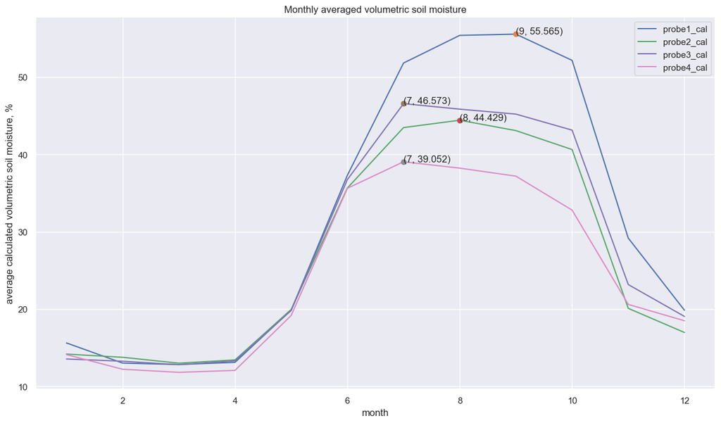

```python
sns.set_theme(rc={'figure.figsize':(15,8.27)})
plot_avg_with_max(monthly_averages_alaska, time_unit='month')
```

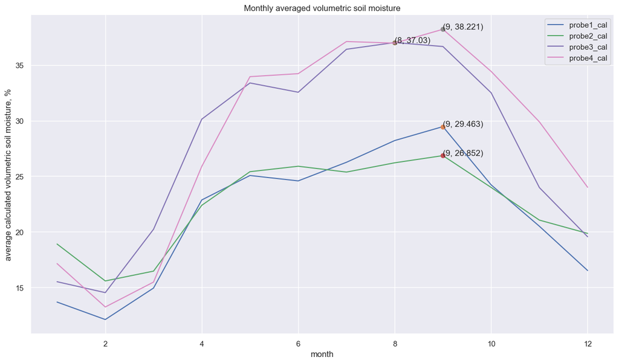

```python
plot_avg_with_max(monthly_averages_alberta, time_unit='month')
```

For Alberta, the months with the highest volumetric soil moisture are August and September.

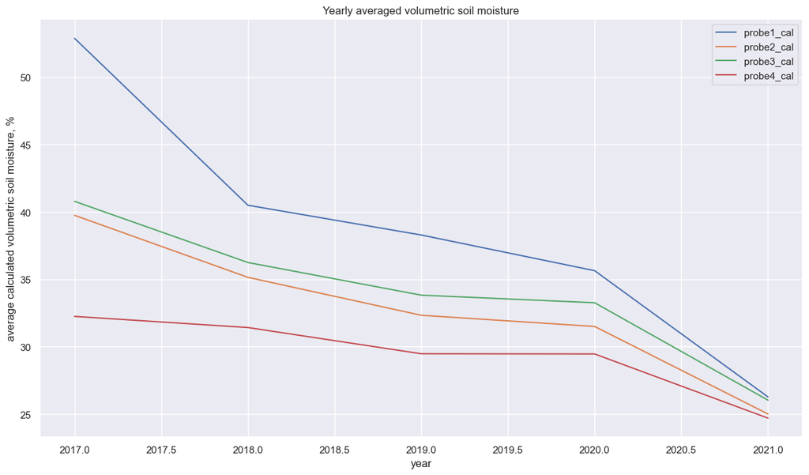

```python
plot_avg_with_max(yearly_averages_alaska, time_unit='year')
```

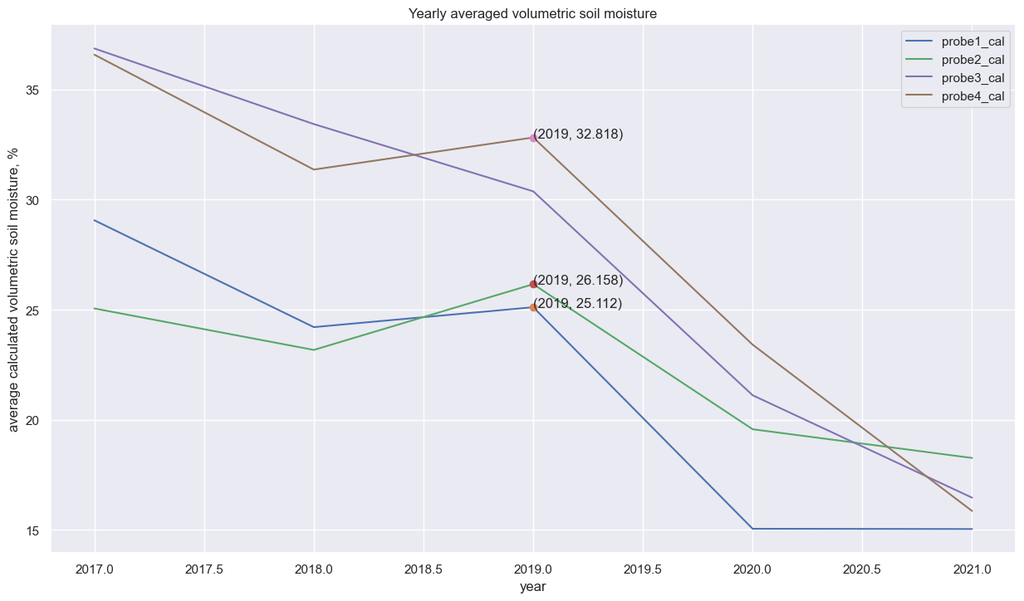

```python
plot_avg_with_max(yearly_averages_alberta, time_unit='year')
```

For both Alaska and Alberta, there appears to be a slow downward trend of volumetric soil moisture content from 2017 to 2021. For Alberta in particular, soil moisture increased slightly in 2019.

### Averages for each region

```python
region_probe_avgs = probe_coeff.drop(
    ['latitude', 'longitude', 'plot', 'probe', 'probe_id', 'record'],
    axis=1
).groupby("area").mean()

pct_cols = [word for word in region_probe_avgs.columns if 'pct' in word]
pct_cols
```

```
['organic_contact_pct',
 'mineral_soil_contact_pct',
 'live_moss_pct',
 'dead_moss_pct',
 'burned_moss_pct',
 'upper_duff_pct',
 'lower_duff_pct']
```

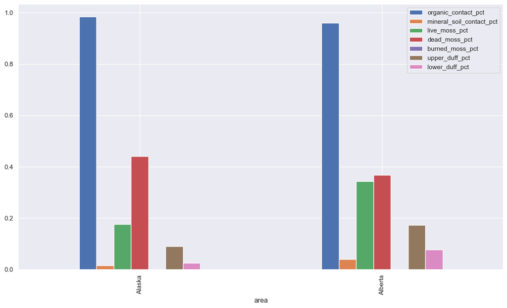

```python
region_probe_avgs[pct_cols].plot(kind='bar')
```

Organic contact pct has the highest percentage than any of the other soil types for both Alaska and Alberta. Trends are mostly the same for both regions except for the live moss percentage; it is the soil type with the 3rd highest percentage for both regions, but it is significantly lower for Alaska than for Alberta.

### Averages for each probe ID

```python
probe_coeff_avgs = probe_coeff.drop(
    ['latitude', 'longitude', 'plot', 'probe', 'record'],
    axis=1
).groupby(["probe_id", "area"]).mean().sort_values(['live_moss_pct'], ascending=False).reset_index(level='area')
```

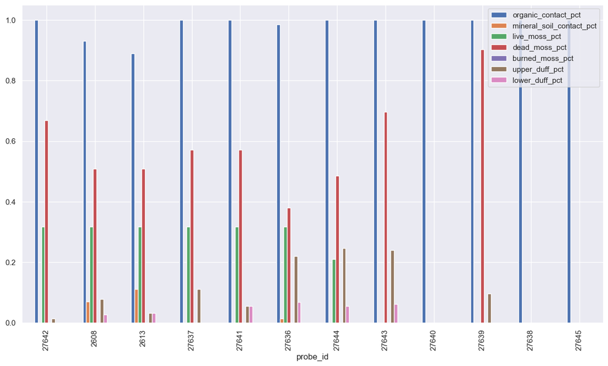

```python
probe_coeff_avgs[probe_coeff_avgs['area']=='Alaska'][pct_cols].plot(kind='bar')
```

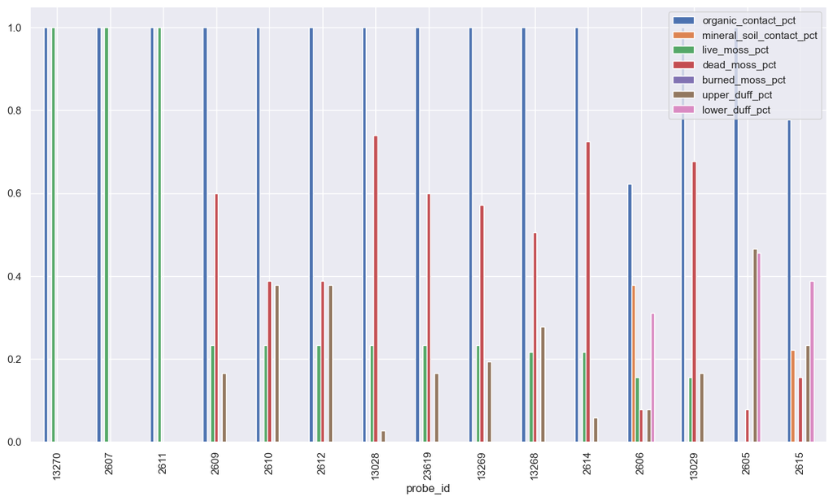

```python
probe_coeff_avgs[probe_coeff_avgs['area']=='Alberta'][pct_cols].plot(kind='bar')
```

Question: what does looking at each probe id tell us? how can it be useful?

### Connection between soil type and moisture content?

```python
probe_coeff.head()
```

|  | area | latitude | longitude | plot | probe | depth_cm | organic_contact_pct | mineral_soil_contact_pct | live_moss_pct | dead_moss_pct | burned_moss_pct | upper_duff_pct | lower_duff_pct | A | B | C | probe_id | record |
| --- | --- | --- | --- | --- | --- | --- | --- | --- | --- | --- | --- | --- | --- | --- | --- | --- | --- | --- |
| 0 | Alaska | 69.63300 | -148.68365 | Sedge 1-1 | 27639-1 | 18 | 1.0 | 0.0 | 0.0 | 0.61111 | 0 | 0.389 | 0.0 | 0.0000 | 3.574484 | -49.072657 | 27639 | 1 |
| 1 | Alaska | 69.63300 | -148.68365 | Sedge 1-1 | 27639-2 | 10 | 1.0 | 0.0 | 0.0 | 1.00000 | 0 | 0.000 | 0.0 | 0.0000 | 3.373000 | -46.350000 | 27639 | 2 |
| 2 | Alaska | 69.63300 | -148.68365 | Sedge 1-1 | 27639-3 | 10 | 1.0 | 0.0 | 0.0 | 1.00000 | 0 | 0.000 | 0.0 | 0.0000 | 3.373000 | -46.350000 | 27639 | 3 |
| 3 | Alaska | 69.63300 | -148.68365 | Sedge 1-1 | 27639-4 | 6 | 1.0 | 0.0 | 0.0 | 1.00000 | 0 | 0.000 | 0.0 | 0.0000 | 3.373000 | -46.350000 | 27639 | 4 |
| 4 | Alaska | 69.63361 | -148.68646 | Sedge 1-4 | 27640-1 | 18 | 1.0 | 0.0 | 0.0 | 0.00000 | 0 | 0.000 | 0.0 | -0.0428 | 5.387100 | -68.443000 | 27640 | 1 |

```python
alaska_cleaned.head()
```

|  | probe_id | time_stamp | record | batt_V_min | pa_us_avg_1 | pa_us_avg_2 | pa_us_avg_3 | pa_us_avg_4 | t109_c_avg | probe1_cal | probe2_cal | probe3_cal | probe4_cal | min | hour | day | month | year |
| --- | --- | --- | --- | --- | --- | --- | --- | --- | --- | --- | --- | --- | --- | --- | --- | --- | --- | --- |
| 0 | 27639 | 2017-07-24 18:00:00 | 0 | 12.87028 | 38.97705 | 38.60135 | 39.82748 | 39.16694 | 5.402802 | 90.250199 | 83.852354 | 87.988090 | 85.760089 | 0 | 18 | 24 | 7 | 2017 |
| 1 | 27639 | 2017-07-24 19:00:00 | 1 | 12.42202 | 38.97570 | 38.60542 | 39.84240 | 39.16965 | 5.405273 | 90.245373 | 83.866082 | 88.038415 | 85.769229 | 0 | 19 | 24 | 7 | 2017 |
| 2 | 27639 | 2017-07-24 20:00:00 | 2 | 12.31709 | 38.97570 | 38.60677 | 39.84375 | 39.17236 | 5.409760 | 90.245373 | 83.870635 | 88.042969 | 85.778370 | 0 | 20 | 24 | 7 | 2017 |
| 3 | 27639 | 2017-07-24 21:00:00 | 3 | 12.24909 | 38.97705 | 38.60813 | 39.84104 | 39.16287 | 5.419159 | 90.250199 | 83.875222 | 88.033828 | 85.746361 | 0 | 21 | 24 | 7 | 2017 |
| 4 | 27639 | 2017-07-24 22:00:00 | 4 | 12.19789 | 38.97163 | 38.61356 | 39.83426 | 39.16287 | 5.421631 | 90.230825 | 83.893538 | 88.010959 | 85.746361 | 0 | 22 | 24 | 7 | 2017 |

```python
def moisture_soil_avg_df(region_df, probe_df):

    '''
    Creates a pandas df that joins the region specific dataframe with the dataframe with the probe coefficient
    and soil specific percentages.

    Arguments:
    region_df (Pandas df) : region specific dataframe with volumetric soil content
     probe_df (Pandas df) : dataframe with information about probes and soil percentages

    Returns:
    df (Pandas df) : joined region and probe dataframes with averages probe specific columns (averages probe 1-4)
                     into one
    '''

    df = pd.merge(region_df, probe_df, on = ['probe_id', 'record'], how='inner')

    probe_period_cols = ['pa_us_avg_1', 'pa_us_avg_2', 'pa_us_avg_3', 'pa_us_avg_4']
    volumetric_cols = ['probe1_cal', 'probe2_cal', 'probe3_cal', 'probe4_cal']

    string_cols = list(df.select_dtypes(include='string').columns)
    extra_cols = ['A', 'B', 'C', 'latitude', 'longitude']

    # calc the averages of probe specific cols
    df['probe_period_avg'] = df[probe_period_cols].mean(axis=1)
    df['volume_avg'] = df[volumetric_cols].mean(axis=1)

    # drop the extra cols
    df = df.drop(np.array(probe_period_cols+volumetric_cols+string_cols+extra_cols), axis = 1)

    return df
```

```python
alaska_and_probe = moisture_soil_avg_df(alaska_cleaned, probe_coeff)
alberta_and_probe = moisture_soil_avg_df(alberta_cleaned, probe_coeff)
```

```python
# group by the probe id
alaska_moisture_soil_avgs = pd.DataFrame(alaska_and_probe.groupby('probe_id').mean())
alberta_moisture_soil_avgs = pd.DataFrame(alberta_and_probe.groupby('probe_id').mean())

# group by
alaska_soil_moisture_corrs = alaska_moisture_soil_avgs[
    pct_cols+['volume_avg']
].drop('burned_moss_pct', axis=1).corr(method='pearson')


alberta_soil_moisture_corrs = alberta_moisture_soil_avgs[
    pct_cols+['volume_avg']
].drop('burned_moss_pct', axis=1).corr(method='pearson')
```

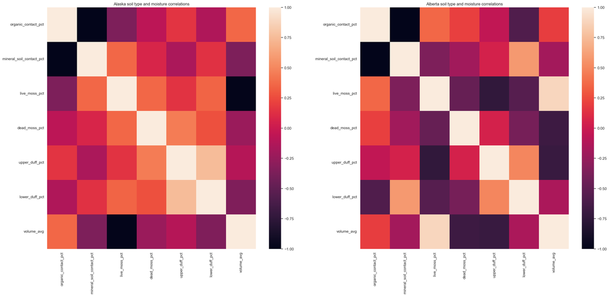

```python
fig = plt.figure()
plt.figure(figsize=(30, 28))

plt.subplot(2, 2, 1)
sns.heatmap(alaska_soil_moisture_corrs)
plt.title('Alaska soil type and moisture correlations')

plt.subplot(2, 2, 2)
sns.heatmap(alberta_soil_moisture_corrs)
plt.title('Alberta soil type and moisture correlations')
```

**Alaska**: Higher volumetric soil content is associated with

- lower percentages of live moss, mineral soil contact, and lower tuff
- moderate/higher percentages of organic contact soil.

**Alberta**: Higher volumetric soil content is associated with

- lower percentages of dead moss and upper duff
- very high percentages of live moss